## Script do Projeto Aprendizagem de Maquina

bibliotecas nescessarias

```r
library(tidyverse)
library(ggplot2)
library(e1071)
library(stringr)
library(rpart)
library(rpart.plot)
library(randomForest)
library(caret)
library(nnet)
library(partykit)
library(plyr)
library(corrplot)
```

### Carregando o banco de dados tratamentos dos dados

```r
#Chamando banco de dados
mush <- read.table(file.choose(), header = T, sep = ",")
# Arquivo mushrooms em csv

#Renomeando cabeçalho
colnames(mush) <- c("classificacao", "formato_chapeu", "superficie_chapeu","cor_chapeu", "mancha", "odor",
"anexo_branquial", "espacamento_branquial", "tamanho_branquial",
"cor_branquial", "formato_caule", "raiz_caule", "superficie_caule_acima_anel", "superficie_caule_abaixo_anel",
"cor_caule_acima_anel", "cor_caule_abaixo_anel", "tipo_veu","cor_veu","numero_aneis","tipo_aneis","cor_esporos", "populacao","habitat")

View(mush)
```

O conjunto de dados contem variaveis categóricas, vamos organizar o banco de dados em variaveis factor e vamos renomar os leves(as classes) dos fatores. Note que como a variavel 17 (“tipo_veu”) so tem uma classe vamos tirar ela do conjunto de dados pois não é significativa para o estudo.

```r
#Transformando todas variáveis em fator
mush <- mush %>% map_df(function(.x) as.factor(.x))

#Renomeando os levels
levels(mush$classificacao) <- c("comestivel", "venenoso")
levels(mush$formato_chapeu) <- c("sino", "conico", "plano", "botão", "baixo_relevo", "convexo")
levels(mush$superficie_chapeu) <- c("fibroso", "rachurado", "escamoso", "liso")
levels(mush$cor_chapeu) <- c("pele", "canela", "vermelho", "cinza", "marrom", "rosa", "verde", "roxo", "branco", "amarelo")
levels(mush$mancha) <- c("nao", "sim")
levels(mush$odor) <- c("amendoa", "creosotose", "falta", "anis", "mofado", "nenhum", "pungente", "picante", "duvidoso")
levels(mush$anexo_branquial) <- c("anexado", "livre")
levels(mush$espacamento_branquial) <- c("fechado", "coroa")
levels(mush$tamanho_branquial) <- c("ampla", "limitado")
levels(mush$cor_branquial) <- c("pele", "vermelho", "cinza", "chocolate", "preto", "marrom", "laranja", "rosa", "verde", "roxo", "branco", "amarelo")
levels(mush$formato_caule) <- c("ampliado", "afunilado")
levels(mush$raiz_caule) <- c("faltante", "bulbosa", "clube", "igual", "enraizado")
levels(mush$superficie_caule_acima_anel) <- c("fibroso", "sedosa", "liso", "escamosa")
levels(mush$superficie_caule_abaixo_anel) <- c("fibrosa", "sedosa", "lisa", "escamosa")
levels(mush$cor_caule_acima_anel) <- c("pele", "canela", "vermelho", "cinza", "marrom", "rosa", "verde", "roxo", "branco", "amarelo")
levels(mush$cor_caule_abaixo_anel) <- c("pele", "canela", "vermelho", "cinza", "marrom", "rosa", "verde", "roxo", "branco", "amarelo")

levels(mush$tipo_veu) <- c("parcial") ###
levels(mush$cor_veu) <- c("marrom", "laranja", "branco", "amarelo")
levels(mush$numero_aneis) <- c("nenhum", "um", "dois")
levels(mush$tipo_aneis) <- c("evanescente", "deslumbrante", "largo", "nenhum", "penso")
levels(mush$cor_esporos) <- c("pele", "chocolate", "preto", "marrom", "laranja", "verde", "roxo", "branco", "amarelo")
levels(mush$populacao) <- c("abundante", "agrupado", "numeroso", "espalhada", "varias", "solitaria")
levels(mush$habitat) <- c("madeira", "grama", "folhas", "campo", "caminhos", "urbano", "desperdicio")

#Retirando a variável "tipo_veu"
mush <- mush[,-17]
```

```r
#Vusualização dos dados
glimpse(mush)
```

```
Rows: 8,124
Columns: 22
$ classificacao                <fct> venenoso, comestivel, comest...
$ formato_chapeu               <fct> convexo, convexo, sino, conv...
$ superficie_chapeu            <fct> escamoso, escamoso, escamoso...
$ cor_chapeu                   <fct> marrom, amarelo, branco, bra...
$ mancha                       <fct> sim, sim, sim, sim, nao, sim...
$ odor                         <fct> pungente, amendoa, anis, pun...
$ anexo_branquial              <fct> livre, livre, livre, livre, ...
$ espacamento_branquial        <fct> fechado, fechado, fechado, f...
$ tamanho_branquial            <fct> limitado, ampla, ampla, limi...
$ cor_branquial                <fct> preto, preto, marrom, marrom...
$ formato_caule                <fct> ampliado, ampliado, ampliado...
$ raiz_caule                   <fct> igual, clube, clube, igual, ...
$ superficie_caule_acima_anel  <fct> liso, liso, liso, liso, liso...
$ superficie_caule_abaixo_anel <fct> lisa, lisa, lisa, lisa, lisa...
$ cor_caule_acima_anel         <fct> roxo, roxo, roxo, roxo, roxo...
$ cor_caule_abaixo_anel        <fct> roxo, roxo, roxo, roxo, roxo...
$ cor_veu                      <fct> branco, branco, branco, bran...
$ numero_aneis                 <fct> um, um, um, um, um, um, um, ...
$ tipo_aneis                   <fct> penso, penso, penso, penso, ...
$ cor_esporos                  <fct> preto, marrom, marrom, preto...
$ populacao                    <fct> espalhada, numeroso, numeros...
$ habitat                      <fct> urbano, grama, campo, urbano...
```

```r
# head(mush)
```

Com isso vemos que as variaveis do banco esta como factor e todas as classes estão renomeadas. Assim o banco esta pronto para as analise seguintes.

```r
attach(mush)
```

### Analise descirtiva

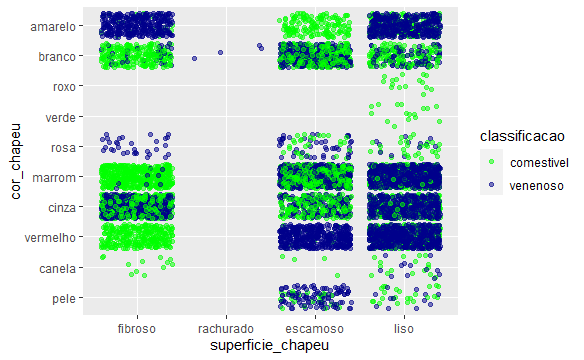

```r
#Relação entre superficie e cor chapeu para discriminar a classificacao
ggplot(mush, aes(x = superficie_chapeu , y = cor_chapeu, col = classificacao)) + geom_jitter(alpha = 0.5) + scale_color_manual(breaks = c("comestivel", "venenoso"), values = c("green", "darkblue"))
```

A superficie fibrosa nos mostrou mais observcoes classificadas como comestivel, enquanto que a lisa mostra o oposto, salvo o caso de quando a cor do chapeu e verde ou roxa. A superficie escamosa com a cor do chapeu amarela tambem nos mostra total seguranca para consumo, enquanto que com o chapeu vermelho totalmente venenoso.

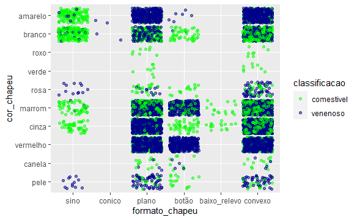

```r
ggplot(mush, aes(x = formato_chapeu, y = cor_chapeu, col = classificacao)) + geom_jitter(alpha = 0.5) +
  scale_color_manual(breaks = c("comestivel", "venenoso"),
                     values = c("green", "darkblue"))
```

O formato de sino se mostra mais seguro para consumo em relacao aos demais formatos, com excessão do no formato de baixo relevo sinaliza da mesma forma, contudo temos poucas observacoes do mesmo.

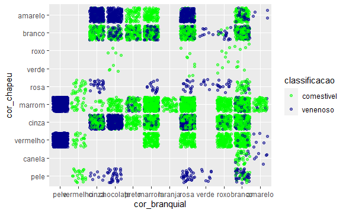

```r
ggplot(mush, aes(x = cor_branquial, y = cor_chapeu, col = classificacao)) +
  geom_jitter(alpha = 0.5) +
  scale_color_manual(breaks = c("comestivel", "venenoso"),
                     values = c("green", "darkblue"))
```

Procurar se ajusta angulo do xlab Vemos que para um cogumelo com cor do chapeu vermelho ele é comestivel quando a cor do branquio é vermelho, marrom, rosa e roxo. Ou quando a cor do branquio é vermelho essa conclusão se dá para quando a cor do chapeu é cor de pele, vermelha, marrom, e rosa.. Quando a cor branquial for cor de pele temos que o cogumelo é venenoso.

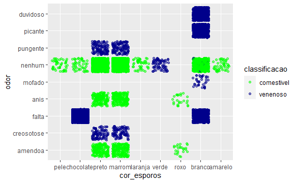

```r
ggplot(mush, aes(x = cor_esporos, y = odor, col = classificacao)) +
  geom_jitter(alpha = 0.5) +
  scale_color_manual(breaks = c("comestivel", "venenoso"),
                     values = c("green", "darkblue"))
```

O odor é definitivamente um preditor informativo. Basicamente, se cheira é duvidoso, picante ou pungente, fique longe. Se cheira a anis ou amêndoa, você pode ir em frente. Se não cheira nada, você tem mais chances de ser comestível do que não. E quando a cor do esporos é preto, marrom ou branco e o odor é duvidoso, picante ou pungente tera chances de ser venenosso, e para a cor dos esporos cor de pele, chocolate, preto, marrom ou laranja e o odor é nenhum ou anis o cocumelho será comestivel.

### Analise modelo, Redução de dimensionalidade e Correlação

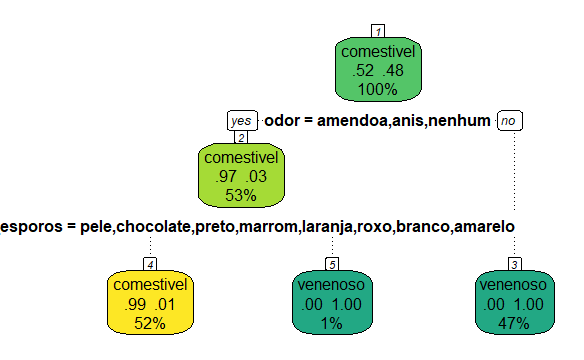

```r
set.seed(2020)
#view(mush)
arvore_mod<-rpart(classificacao ~ ., data = mush)
#________________________________________________________________________________


#Faz o plot da arvore de decissão
rpart.plot(arvore_mod , extra = 104, box.palette = "YlGnBl",
           branch.lty = 3, nn = TRUE)
```

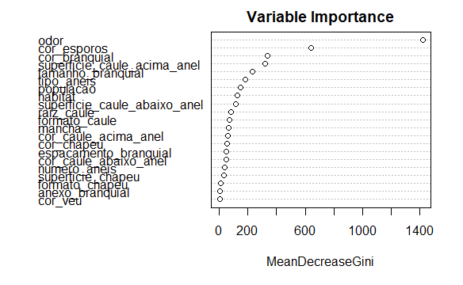

```r
# Outra arvore de decissão
# a <- ctree(classificacao ~ ., mush)
# plot(a)

rf = randomForest(classificacao ~ .,
                  ntree = 100,
                  data = mush)
#plot(rf)
varImpPlot(rf,
           sort = T,
           main = "Variable Importance")
```

```r
rf$importance[rf$importance>=145,]
```

```
                       odor           tamanho_branquial
                  1421.3041                    232.6567
              cor_branquial superficie_caule_acima_anel
                   336.6634                    320.0237
                 tipo_aneis                 cor_esporos
                   181.9546                    639.3001
                  populacao
                   147.9658
```

Obtemos as importancias das variaveis ultilizando o random floreste e escolhemos o corte de 145, onde as variaveis com importancia maior que 15 serão consideradas nos estudos dos modelos adiante, assim conseguindo fazer uma redução de dimensionalidade onde o banco com 21 variáveis exceto a variavel resposta, vemos que 7 variaveis tem grau de importancia alto. Note que no plote das variáveis “odor” e “cor_esporos” vemos que a separação de cogumelos comestivel e venenoso fica nitida e vemos que essas duas variaveis são as que apresenta maior grau de importância, note também que essas duas variáveis são as que ficaram na arvore de decissão. Note também que para o plote com a variável “formato_chapeu” tem grau de importancia muito e notamos que não fica nitido a separação de cogumelos comestivel e venenosso.

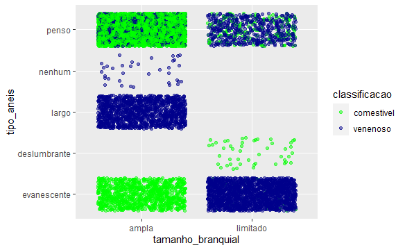

```r
ggplot(mush, aes(x = tamanho_branquial, y = tipo_aneis, col = classificacao)) +
  geom_jitter(alpha = 0.5) +
  scale_color_manual(breaks = c("comestivel", "venenoso"),
                     values = c("green", "darkblue"))
```

Note que apois apresentar o grau de importancia das variaveis, fizemos o plote do “tipo_anel” com o “tamanho_branquial” e coloramos com base nos cocumelos comestiveis e venenossos. E vemos que essas duas variaveis são bem nitidas a separação de comestivel e venenosso, exceto para a classe “penso” no tipo_anel.

Para Analizarmos a correlações das variaveis vamos criar um subbanco com a variaveis alvo e as variaveis com grau de importancia alto, depois como o banco esta no formato de factor vamos transformar o banco em numerico para poder calcular as correlações

```r
# vamos pegar as variaveis com grau de importancia alto
df<-subset(mush, select = c(1,6,9,10,13,19,20,21))

# Transformando o banco em numerico
df$classificacao<-as.integer(mapvalues(df$classificacao,c("comestivel", "venenoso"),1:2))
df$odor<-as.integer(mapvalues(df$odor, c("amendoa", "creosotose", "falta", "anis", "mofado", "nenhum", "pungente", "picante", "duvidoso"),1:9))
df$tamanho_branquial<-as.integer(mapvalues(df$tamanho_branquial, c("ampla", "limitado"),1:2))
df$cor_branquial<-as.integer(mapvalues(df$cor_branquial, c("pele", "vermelho", "cinza", "chocolate", "preto", "marrom", "laranja", "rosa", "verde", "roxo", "branco", "amarelo"),1:12))
df$superficie_caule_acima_anel<-as.integer(mapvalues(df$superficie_caule_acima_anel, c("fibroso", "sedosa", "liso", "escamosa"),1:4))
df$tipo_aneis<-as.integer(mapvalues(df$tipo_aneis, c("evanescente", "deslumbrante", "largo", "nenhum", "penso"),1:5))
df$cor_esporos<-as.integer(mapvalues(df$cor_esporos, c("pele", "chocolate", "preto", "marrom", "laranja", "verde", "roxo", "branco", "amarelo"),1:9))
df$populacao<-as.integer(mapvalues(df$populacao, c("abundante", "agrupado", "numeroso", "espalhada", "varias", "solitaria"),1:6))

# Vamos renomar as variaveis para ficar mais agradavel a saida
#tamanho_branquial = , superficie_caule_acima_anel = superf_c_a_anel
colnames(df)<-c("classificacao", "odor","tam_branquial",
                "cor_branquial", "superf_c_a_anel","tipo_aneis","cor_esporos", "populacao")

glimpse(df)
```

```
Rows: 8,124
Columns: 8
$ classificacao   <int> 2, 1, 1, 2, 1, 1, 1, 1, 2, 1, 1, 1, 1, 2,...
$ odor            <int> 7, 1, 4, 7, 6, 1, 1, 4, 7, 1, 4, 1, 1, 7,...
$ tam_branquial   <int> 2, 1, 1, 2, 1, 1, 1, 1, 2, 1, 1, 1, 1, 2,...
$ cor_branquial   <int> 5, 5, 6, 6, 5, 6, 3, 6, 8, 3, 3, 6, 11, 5...
$ superf_c_a_anel <int> 3, 3, 3, 3, 3, 3, 3, 3, 3, 3, 3, 3, 3, 3,...
$ tipo_aneis      <int> 5, 5, 5, 5, 1, 5, 5, 5, 5, 5, 5, 5, 5, 5,...
$ cor_esporos     <int> 3, 4, 4, 3, 4, 3, 3, 4, 3, 3, 4, 3, 4, 4,...
$ populacao       <int> 4, 3, 3, 4, 1, 3, 3, 4, 5, 4, 3, 4, 4, 5,...
```

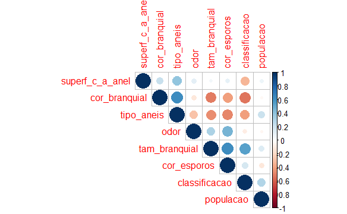

```r
# Calculando as correlações
M<-cor(df)

corrplot(M,type = "upper", order = "hclust", sig.level = 0.01, insig = "blank")
```

### Validação Cruzada

A seguir vamos fazer a analises com o banco de dados, fazendo validação cruzada usando k-fold igual a 10 e cv igual a 10, note que a variavel resposta é categorica e os banco de treinamento e de teste que obtemos na validação cruzada precisa ter a mesma proporssão, onde no banco original a variavel “classificação” apresenta 0.52 comestivel e 0.48 venenosso e os bancos de teste e treinamento a variavel classificação precisar ter essas mesmas proporção.  
Como estamos lidando com um problema de classificação, na validação cruzada calculamos a matriz de confussão e obtemos o seguintes indicadores Sensitivity, Specificity, Prevalence, PPV(Pos Pred Value), NPV( Neg Pred Value), Detection Rate, Detection Prevalence, Balanced Accuracy, Precision , Recall e F1.

Diante de outros metodos de modelagem, a redução de dimensionalidade não foi satisfatoria, como no caso do knn, onde este precisou de 19 das 22 variaveis, para sua contrução. #####

```r
### Vamos fazer a validação cruzada para as variáveis com grau de importancia alto

### Organizando o banco
mush.pronto<-subset(mush, select = c(1,3,4,5,6,8,9,10,11,12,13,14,15,16,18,19,20,21,22))

#view(mush.pronto)
# Vamos colocar 90% para o banco de treinamento e 10% para o banco de teste
K=10
cv = 10

R.modelo.arvore.k<-matrix(NA, nrow = K,ncol = 11)
R.modelo.random.k<-matrix(NA, nrow = K,ncol = 11)
R.modelo.Knn.k<-matrix(NA, nrow = K,ncol = 11)
R.modelo.SVM.k<-matrix(NA, nrow = K,ncol = 11)
R.modelo.pred.logit_mod.k<-matrix(NA, nrow = K,ncol = 11)
R.modelo.percep.k<-matrix(NA, nrow = K,ncol = 11)

set.seed(2020)
######## Interacoes K-Fold ##########
for(t in 1:K)
{

  R.modelo.arvore.cv<-matrix(NA, nrow = cv,ncol = 11)
  R.modelo.random.cv<-matrix(NA, nrow = cv,ncol = 11)
  R.modelo.Knn.cv<-matrix(NA, nrow = cv,ncol = 11)
  R.modelo.SVM.cv<-matrix(NA, nrow = cv,ncol = 11)
  R.modelo.pred.logit_mod.cv<-matrix(NA, nrow = cv,ncol = 11)
  R.modelo.percep.cv<-matrix(NA, nrow = cv,ncol = 11)

  #group <- sample(group)
  amostra<-createDataPartition(y = mush.pronto$classificacao, times = 10, p = 0.9, list = FALSE)
  # Esta função é muito boa pois quando formos para a tarefa de classificação
  # ele mantem a proporção das classes que é comestivel 0.52 , venenoso 0.48

  ######## Interacoes CrossValidation ##########

  for(i in 1:cv){

    ##################################################
    round(prop.table(table(mush.pronto$classificacao)), 2)
    #Variaveis temporarias Treinamento
    mush.Trein<-mush.pronto[amostra[,i],]
    print(round(prop.table(table(mush.Trein$classificacao)), 2))

    #Variaveis temporarias Treinamento
    mush.Test<-mush.pronto[-amostra[,i],]
    print(round(prop.table(table(mush.Trein$classificacao)), 2))


    ############ MODELOS LOGISTICO Multinomial ########
    fit.logit_mod <- multinom(classificacao ~ ., data = mush.Trein)
    pred.logit_mod<-predict(fit.logit_mod, newdata = mush.Test[,-1], type = "class")

    R.modelo.pred.logit_mod.cv[i,]<-confusionMatrix(data=pred.logit_mod, reference = mush.Test$classificacao, positive="comestivel")$byClass


    ############ MODELOS Arvore ########
    fit.arvore<-rpart(classificacao ~ . , data = mush.Trein)
    pred.arvore<-predict(fit.arvore, newdata = mush.Test[,-1], type = "class")
    #Vamos fazer a matriz de confusão
    R.modelo.arvore.cv[i,]<-confusionMatrix(data=pred.arvore, reference = mush.Test$classificacao, positive="comestivel")$byClass

    ############ MODELOS Random florest ########

    fit.randon<-randomForest(classificacao ~ . , data = mush.Trein)
    pred.random<-predict(fit.randon, newdata = mush.Test[,-1], type = "class")
    #Vamos fazer a matriz de confusão
    R.modelo.random.cv[i,]<-confusionMatrix(data=pred.random, reference = mush.Test$classificacao, positive="comestivel")$byClass


    ############ MODELOS Knn ########
    fit.knn<-knn3(classificacao ~ . , data = mush.Trein,k=6)
    pred.knn<-predict(fit.knn, newdata = mush.Test[,-1], type = "class")
    #Vamos fazer a matriz de confusão
    R.modelo.Knn.cv[i,]<-confusionMatrix(data=pred.knn, reference = mush.Test$classificacao, positive="comestivel")$byClass



    ############ MODELOS SVM ########
    fit.svm<-svm(classificacao ~ . , data = mush.Trein, type='C-classification', kernel='radial')
    pred.svm<-predict(fit.svm, newdata = mush.Test[,-1], type = "class")
    #Vamos fazer a matriz de confusão
    R.modelo.SVM.cv[i,]<-confusionMatrix(data=pred.svm, reference = mush.Test$classificacao, positive="comestivel")$byClass

    ########### MODELO Perceptron ########
    fit.percep<-nnet(classificacao ~ . , data = mush.Trein,size = 1)
    pred.percep<-predict(fit.percep, newdata = mush.Test[,-1], type = "class")
    pred.percep<-as.factor(pred.percep)
    #Vamos fazer a matriz de confusão
    R.modelo.percep.cv[i,]<-confusionMatrix(data=pred.percep, reference = mush.Test$classificacao, positive="comestivel")$byClass

  }

  # Salvando os resultados do for anterior
  R.modelo.arvore.k[t,]<-colMeans(R.modelo.arvore.cv)
  R.modelo.random.k[t,]<-colMeans(R.modelo.random.cv)
  R.modelo.Knn.k[t,]<-colMeans(R.modelo.Knn.cv)
  R.modelo.SVM.k[t,]<-colMeans(R.modelo.SVM.cv)
  R.modelo.pred.logit_mod.k[t,]<-colMeans(R.modelo.pred.logit_mod.cv)
  R.modelo.percep.k[t,]<-colMeans(R.modelo.percep.cv)

}

R.Arvore<-colMeans(R.modelo.arvore.k)
R.Random<-colMeans(R.modelo.random.k)
R.Knn<-colMeans(R.modelo.Knn.k)
R.SVM<-colMeans(R.modelo.SVM.k)
R.Logis.Mod<-colMeans(R.modelo.pred.logit_mod.k)
R.perceptron<-colMeans(R.modelo.percep.k)

Result.Matriz<-matrix(NA,nrow = 11,ncol = 6)
Result.Matriz[,1]<-R.Arvore
Result.Matriz[,2]<-R.Random
Result.Matriz[,3]<-R.SVM
Result.Matriz[,4]<-R.Knn
Result.Matriz[,5]<-R.Logis.Mod
Result.Matriz[,6]<-R.perceptron
row.names(Result.Matriz)<-c("Sensitivity","Specificity","Pos Pred Value","Neg Pred Value",
                           "Precision","Recall","F1","Prevalence","Detection Rate",
                           "Detection Prevalence","Balanced Accuracy")
colnames(Result.Matriz)<-c("Arvore", "Random","SVM","Knn","Logist.Mult","Perceptron")
```

```r
Result.Matriz
```

```
                        Arvore    Random       SVM       Knn
Sensitivity          1.0000000 1.0000000 1.0000000 1.0000000
Specificity          0.9878005 1.0000000 0.9959591 0.9997442
Pos Pred Value       0.9887892 1.0000000 0.9962592 0.9997631
Neg Pred Value       1.0000000 1.0000000 1.0000000 1.0000000
Precision            0.9887892 1.0000000 0.9962592 0.9997631
Recall               1.0000000 1.0000000 1.0000000 1.0000000
F1                   0.9943583 1.0000000 0.9981243 0.9998813
Prevalence           0.5178792 0.5178792 0.5178792 0.5178792
Detection Rate       0.5178792 0.5178792 0.5178792 0.5178792
Detection Prevalence 0.5237608 0.5178792 0.5198274 0.5180025
Balanced Accuracy    0.9939003 1.0000000 0.9979795 0.9998721
                     Logist.Mult Perceptron
Sensitivity            1.0000000  0.9949524
Specificity            1.0000000  0.9495396
Pos Pred Value         1.0000000  0.9590368
Neg Pred Value         1.0000000  0.9947277
Precision              1.0000000  0.9590368
Recall                 1.0000000  0.9949524
F1                     1.0000000  0.9755881
Prevalence             0.5178792  0.5178792
Detection Rate         0.5178792  0.5152651
Detection Prevalence   0.5178792  0.5395931
Balanced Accuracy      1.0000000  0.9722460
```

Apois rodar a validação cruzada para os modelos “Arvore de dercisão”,“Random florest”,“SVM”,“Knn”,“Logistica Multinomial” e “Perceptron” vemos a saida com os indicadores falados anteriormente e vemos que o modelo “Random florest” e “Logistica Multinomial” apresenta a accuracy igual a 1. No geral todos os modelos apresentam resultados muitos bons, mais vemos que os dois melhores modelos foram “Random florest” e “Logistica Multinomial”.

Fazendo a validação cruzada para as 8 variaveis que continuaram apois a redução de dimenscionalidade. Como inicialmento o modelo Knn não redou para esses dados com a redução nessa validação retiramos o modelo knn.

```r
### Vamos fazer a validação cruzada para as variáveis com grau de importancia alto

### Organizando o banco
mush.pronto<-subset(mush, select = c(1,6,9,10,13,19,20,21))


# Vamos colocar 90% para o banco de treinamento e 10% para o banco de teste
K=10
cv = 10

R.modelo.arvore.k<-matrix(NA, nrow = K,ncol = 11)
R.modelo.random.k<-matrix(NA, nrow = K,ncol = 11)
#R.modelo.Knn.k<-matrix(NA, nrow = K,ncol = 11)
R.modelo.SVM.k<-matrix(NA, nrow = K,ncol = 11)
R.modelo.pred.logit_mod.k<-matrix(NA, nrow = K,ncol = 11)
R.modelo.percep.k<-matrix(NA, nrow = K,ncol = 11)

set.seed(2020)
######## Interacoes K-Fold ##########
for(t in 1:K)
{

  R.modelo.arvore.cv<-matrix(NA, nrow = cv,ncol = 11)
  R.modelo.random.cv<-matrix(NA, nrow = cv,ncol = 11)
  #R.modelo.Knn.cv<-matrix(NA, nrow = cv,ncol = 11)
  R.modelo.SVM.cv<-matrix(NA, nrow = cv,ncol = 11)
  R.modelo.pred.logit_mod.cv<-matrix(NA, nrow = cv,ncol = 11)
  R.modelo.percep.cv<-matrix(NA, nrow = cv,ncol = 11)

  #group <- sample(group)
  amostra<-createDataPartition(y = mush.pronto$classificacao, times = 10, p = 0.9, list = FALSE)
  # Esta função é muito boa pois quando formos para a tarefa de classificação
  # ele mantem a proporção das classes que é comestivel 0.52 , venenoso 0.48

  ######## Interacoes CrossValidation ##########

  for(i in 1:cv){

    ##################################################
    round(prop.table(table(mush.pronto$classificacao)), 2)
    #Variaveis temporarias Treinamento
    mush.Trein<-mush.pronto[amostra[,i],]
    print(round(prop.table(table(mush.Trein$classificacao)), 2))

    #Variaveis temporarias Treinamento
    mush.Test<-mush.pronto[-amostra[,i],]
    print(round(prop.table(table(mush.Trein$classificacao)), 2))


    ############ MODELOS LOGISTICO Multinomial ########
    fit.logit_mod <- multinom(classificacao ~ ., data = mush.Trein)
    pred.logit_mod<-predict(fit.logit_mod, newdata = mush.Test[,-1], type = "class")

    R.modelo.pred.logit_mod.cv[i,]<-confusionMatrix(data=pred.logit_mod, reference = mush.Test$classificacao, positive="comestivel")$byClass


    ############ MODELOS Arvore ########
    fit.arvore<-rpart(classificacao ~ . , data = mush.Trein)
    pred.arvore<-predict(fit.arvore, newdata = mush.Test[,-1], type = "class")
    #Vamos fazer a matriz de confusão
    R.modelo.arvore.cv[i,]<-confusionMatrix(data=pred.arvore, reference = mush.Test$classificacao, positive="comestivel")$byClass

    ############ MODELOS Random florest ########

    fit.randon<-randomForest(classificacao ~ . , data = mush.Trein)
    pred.random<-predict(fit.randon, newdata = mush.Test[,-1], type = "class")
    #Vamos fazer a matriz de confusão
    R.modelo.random.cv[i,]<-confusionMatrix(data=pred.random, reference = mush.Test$classificacao, positive="comestivel")$byClass


    ############ MODELOS Knn ########
    #fit.knn<-knn3(classificacao ~ . , data = mush.Trein,k=6)
    #pred.knn<-predict(fit.knn, newdata = mush.Test[,-1], type = "class")
    #Vamos fazer a matriz de confusão
    #R.modelo.Knn.cv[i,]<-confusionMatrix(data=pred.knn, reference = mush.Test$classificacao, positive="comestivel")$byClas

    ############ MODELOS SVM ########
    fit.svm<-svm(classificacao ~ . , data = mush.Trein, type='C-classification', kernel='radial')
    pred.svm<-predict(fit.svm, newdata = mush.Test[,-1], type = "class")
    #Vamos fazer a matriz de confusão
    R.modelo.SVM.cv[i,]<-confusionMatrix(data=pred.svm, reference = mush.Test$classificacao, positive="comestivel")$byClass

    ########### MODELO Perceptron ########
    fit.percep<-nnet(classificacao ~ . , data = mush.Trein,size = 1)
    pred.percep<-predict(fit.percep, newdata = mush.Test[,-1], type = "class")
    pred.percep<-as.factor(pred.percep)
    #Vamos fazer a matriz de confusão
    R.modelo.percep.cv[i,]<-confusionMatrix(data=pred.percep, reference = mush.Test$classificacao, positive="comestivel")$byClass

  }

  # Salvando os resultados do for anterior
  R.modelo.arvore.k[t,]<-colMeans(R.modelo.arvore.cv)
  R.modelo.random.k[t,]<-colMeans(R.modelo.random.cv)
  #R.modelo.Knn.k[t,]<-colMeans(R.modelo.Knn.cv)
  R.modelo.SVM.k[t,]<-colMeans(R.modelo.SVM.cv)
  R.modelo.pred.logit_mod.k[t,]<-colMeans(R.modelo.pred.logit_mod.cv)
  R.modelo.percep.k[t,]<-colMeans(R.modelo.percep.cv)

}

R.Arvore<-colMeans(R.modelo.arvore.k)
R.Random<-colMeans(R.modelo.random.k)
#R.Knn<-colMeans(R.modelo.Knn.k)
R.SVM<-colMeans(R.modelo.SVM.k)
R.Logis.Mod<-colMeans(R.modelo.pred.logit_mod.k)
R.perceptron<-colMeans(R.modelo.percep.k)

Result.Matriz<-matrix(NA,nrow = 11,ncol = 6)
Result.Matriz[,1]<-R.Arvore
Result.Matriz[,2]<-R.Random
Result.Matriz[,3]<-R.SVM
#Result.Matriz[,4]<-R.Knn
Result.Matriz[,5]<-R.Logis.Mod
Result.Matriz[,6]<-R.perceptron
row.names(Result.Matriz)<-c("Sensitivity","Specificity","Pos Pred Value","Neg Pred Value",
                           "Precision","Recall","F1","Prevalence","Detection Rate",
                           "Detection Prevalence","Balanced Accuracy")
colnames(Result.Matriz)<-c("Arvore", "Random","SVM","Knn","Logist.Mult","Perceptron")
```

```r
Result.Matriz
```

```
                        Arvore    Random       SVM Knn Logist.Mult
Sensitivity          1.0000000 1.0000000 1.0000000  NA   1.0000000
Specificity          0.9879028 1.0000000 0.9879028  NA   1.0000000
Pos Pred Value       0.9888868 1.0000000 0.9888868  NA   1.0000000
Neg Pred Value       1.0000000 1.0000000 1.0000000  NA   1.0000000
Precision            0.9888868 1.0000000 0.9888868  NA   1.0000000
Recall               1.0000000 1.0000000 1.0000000  NA   1.0000000
F1                   0.9944065 1.0000000 0.9944065  NA   1.0000000
Prevalence           0.5178792 0.5178792 0.5178792  NA   0.5178792
Detection Rate       0.5178792 0.5178792 0.5178792  NA   0.5178792
Detection Prevalence 0.5237115 0.5178792 0.5237115  NA   0.5178792
Balanced Accuracy    0.9939514 1.0000000 0.9939514  NA   1.0000000
                     Perceptron
Sensitivity           0.9971190
Specificity           0.9582097
Pos Pred Value        0.9660379
Neg Pred Value        0.9966505
Precision             0.9660379
Recall                0.9971190
F1                    0.9804889
Prevalence            0.5178792
Detection Rate        0.5163872
Detection Prevalence  0.5365351
Balanced Accuracy     0.9776644
```

### Rodando os modelos para todos os dados

Vamos separar o banco de dados em 80% em dados de treinamento e 20% em dados de teste e vamos verificar a matiz de confussão para esses modelos estudados.

```r
# Vamos fazer uma amostra com 80% para o banco de treinamento e 20% para banco de Test
set.seed(2020)

  amostra<-createDataPartition(y = mush$classificacao, times = 1, p = 0.8, list = FALSE)

##################################################
    #Variaveis temporarias Treinamento
    Mush.Trein<-mush[amostra[,1],]

    #Variaveis temporarias Treinamento
    Mush.Test<-mush[-amostra[,1],]

    ############ MODELOS LOGISTICO Multinomial ########
    fit.logit_mod <- multinom(classificacao ~ ., data = Mush.Trein)
    pred.logit_mod<-predict(fit.logit_mod, newdata = Mush.Test[,-1], type = "class")

    confusionMatrix(data=pred.logit_mod, reference = Mush.Test$classificacao, positive="comestivel")
```

```
Confusion Matrix and Statistics

            Reference
Prediction   comestivel venenoso
  comestivel        841        0
  venenoso            0      783

               Accuracy : 1
                 95% CI : (0.9977, 1)
    No Information Rate : 0.5179
    P-Value [Acc > NIR] : < 2.2e-16

                  Kappa : 1

 Mcnemar's Test P-Value : NA

            Sensitivity : 1.0000
            Specificity : 1.0000
         Pos Pred Value : 1.0000
         Neg Pred Value : 1.0000
             Prevalence : 0.5179
         Detection Rate : 0.5179
   Detection Prevalence : 0.5179
      Balanced Accuracy : 1.0000

       'Positive' Class : comestivel
```

```r
    ############ MODELOS Arvore ########
    fit.arvore<-rpart(classificacao ~ . , data = Mush.Trein)
    pred.arvore<-predict(fit.arvore, newdata = Mush.Test[,-1], type = "class")
    #Vamos fazer a matriz de confusão
    confusionMatrix(data=pred.arvore, reference = Mush.Test$classificacao, positive="comestivel")
```

```
Confusion Matrix and Statistics

            Reference
Prediction   comestivel venenoso
  comestivel        841        6
  venenoso            0      777

               Accuracy : 0.9963
                 95% CI : (0.992, 0.9986)
    No Information Rate : 0.5179
    P-Value [Acc > NIR] : < 2e-16

                  Kappa : 0.9926

 Mcnemar's Test P-Value : 0.04123

            Sensitivity : 1.0000
            Specificity : 0.9923
         Pos Pred Value : 0.9929
         Neg Pred Value : 1.0000
             Prevalence : 0.5179
         Detection Rate : 0.5179
   Detection Prevalence : 0.5216
      Balanced Accuracy : 0.9962

       'Positive' Class : comestivel
```

```r
    ############ MODELOS Random florest ########

    fit.randon<-randomForest(classificacao ~ . , data = Mush.Trein)
    pred.random<-predict(fit.randon, newdata = Mush.Test[,-1], type = "class")
    #Vamos fazer a matriz de confusão
    confusionMatrix(data=pred.random, reference = Mush.Test$classificacao, positive="comestivel")
```

```
Confusion Matrix and Statistics

            Reference
Prediction   comestivel venenoso
  comestivel        841        0
  venenoso            0      783

               Accuracy : 1
                 95% CI : (0.9977, 1)
    No Information Rate : 0.5179
    P-Value [Acc > NIR] : < 2.2e-16

                  Kappa : 1

 Mcnemar's Test P-Value : NA

            Sensitivity : 1.0000
            Specificity : 1.0000
         Pos Pred Value : 1.0000
         Neg Pred Value : 1.0000
             Prevalence : 0.5179
         Detection Rate : 0.5179
   Detection Prevalence : 0.5179
      Balanced Accuracy : 1.0000

       'Positive' Class : comestivel
```

```r
    ############ MODELOS Knn ########
    fit.knn<-knn3(classificacao ~ . , data = Mush.Trein,k=6)
    pred.knn<-predict(fit.knn, newdata = Mush.Test[,-1], type = "class")
    #Vamos fazer a matriz de confusão
    confusionMatrix(data=pred.knn, reference = Mush.Test$classificacao, positive="comestivel")
```

```
Confusion Matrix and Statistics

            Reference
Prediction   comestivel venenoso
  comestivel        841        0
  venenoso            0      783

               Accuracy : 1
                 95% CI : (0.9977, 1)
    No Information Rate : 0.5179
    P-Value [Acc > NIR] : < 2.2e-16

                  Kappa : 1

 Mcnemar's Test P-Value : NA

            Sensitivity : 1.0000
            Specificity : 1.0000
         Pos Pred Value : 1.0000
         Neg Pred Value : 1.0000
             Prevalence : 0.5179
         Detection Rate : 0.5179
   Detection Prevalence : 0.5179
      Balanced Accuracy : 1.0000

       'Positive' Class : comestivel
```

```r
    ############ MODELOS SVM ########
    fit.svm<-svm(classificacao ~ . , data = Mush.Trein, type='C-classification', kernel='radial')
    pred.svm<-predict(fit.svm, newdata = Mush.Test[,-1], type = "class")
    #Vamos fazer a matriz de confusão
    confusionMatrix(data=pred.svm, reference = Mush.Test$classificacao, positive="comestivel")
```

```
Confusion Matrix and Statistics

            Reference
Prediction   comestivel venenoso
  comestivel        841        2
  venenoso            0      781

               Accuracy : 0.9988
                 95% CI : (0.9956, 0.9999)
    No Information Rate : 0.5179
    P-Value [Acc > NIR] : <2e-16

                  Kappa : 0.9975

 Mcnemar's Test P-Value : 0.4795

            Sensitivity : 1.0000
            Specificity : 0.9974
         Pos Pred Value : 0.9976
         Neg Pred Value : 1.0000
             Prevalence : 0.5179
         Detection Rate : 0.5179
   Detection Prevalence : 0.5191
      Balanced Accuracy : 0.9987

       'Positive' Class : comestivel
```

```r
    ########### MODELO Perceptron ########
    fit.percep<-nnet(classificacao ~ . , data = Mush.Trein,size = 1)
    pred.percep<-predict(fit.percep, newdata = Mush.Test[,-1], type = "class")
    pred.percep<-as.factor(pred.percep)
    #Vamos fazer a matriz de confusão
    confusionMatrix(data=pred.percep, reference = Mush.Test$classificacao, positive="comestivel")
```

```
Confusion Matrix and Statistics

            Reference
Prediction   comestivel venenoso
  comestivel        841       21
  venenoso            0      762

               Accuracy : 0.9871
                 95% CI : (0.9803, 0.992)
    No Information Rate : 0.5179
    P-Value [Acc > NIR] : < 2.2e-16

                  Kappa : 0.9741

 Mcnemar's Test P-Value : 1.275e-05

            Sensitivity : 1.0000
            Specificity : 0.9732
         Pos Pred Value : 0.9756
         Neg Pred Value : 1.0000
             Prevalence : 0.5179
         Detection Rate : 0.5179
   Detection Prevalence : 0.5308
      Balanced Accuracy : 0.9866

       'Positive' Class : comestivel
```

### Rodando os modelos para os dados apois a redução

Vamos separar o banco de dados em 80% em dados de treinamento e 20% em dados de teste e vamos verificar a matiz de confussão para esses modelos estudados.

#### Nesse não estamos considerando todas as variaveis

```r
### Organizando o banco
Mush.P<-subset(mush, select = c(1,6,9,10,13,19,20,21))

# Vamos fazer uma amostra com 80% para o banco de treinamento e 20% para banco de Test
set.seed(2020)

  amostra<-createDataPartition(y = Mush.P$classificacao, times = 1, p = 0.8, list = FALSE)

##################################################
    #Variaveis temporarias Treinamento
    Mush.Trein<-Mush.P[amostra[,1],]

    #Variaveis temporarias Treinamento
    Mush.Test<-Mush.P[-amostra[,1],]

    ############ MODELOS LOGISTICO Multinomial ########
    fit.logit_mod <- multinom(classificacao ~ ., data = Mush.Trein)
    pred.logit_mod<-predict(fit.logit_mod, newdata = Mush.Test[,-1], type = "class")

    confusionMatrix(data=pred.logit_mod, reference = Mush.Test$classificacao, positive="comestivel")
```

```
Confusion Matrix and Statistics

            Reference
Prediction   comestivel venenoso
  comestivel        841        0
  venenoso            0      783

               Accuracy : 1
                 95% CI : (0.9977, 1)
    No Information Rate : 0.5179
    P-Value [Acc > NIR] : < 2.2e-16

                  Kappa : 1

 Mcnemar's Test P-Value : NA

            Sensitivity : 1.0000
            Specificity : 1.0000
         Pos Pred Value : 1.0000
         Neg Pred Value : 1.0000
             Prevalence : 0.5179
         Detection Rate : 0.5179
   Detection Prevalence : 0.5179
      Balanced Accuracy : 1.0000

       'Positive' Class : comestivel
```

```r
    ############ MODELOS Arvore ########
    fit.arvore<-rpart(classificacao ~ . , data = Mush.Trein)
    pred.arvore<-predict(fit.arvore, newdata = Mush.Test[,-1], type = "class")
    #Vamos fazer a matriz de confusão
    confusionMatrix(data=pred.arvore, reference = Mush.Test$classificacao, positive="comestivel")
```

```
Confusion Matrix and Statistics

            Reference
Prediction   comestivel venenoso
  comestivel        841        6
  venenoso            0      777

               Accuracy : 0.9963
                 95% CI : (0.992, 0.9986)
    No Information Rate : 0.5179
    P-Value [Acc > NIR] : < 2e-16

                  Kappa : 0.9926

 Mcnemar's Test P-Value : 0.04123

            Sensitivity : 1.0000
            Specificity : 0.9923
         Pos Pred Value : 0.9929
         Neg Pred Value : 1.0000
             Prevalence : 0.5179
         Detection Rate : 0.5179
   Detection Prevalence : 0.5216
      Balanced Accuracy : 0.9962

       'Positive' Class : comestivel
```

```r
    ############ MODELOS Random florest ########

    fit.randon<-randomForest(classificacao ~ . , data = Mush.Trein)
    pred.random<-predict(fit.randon, newdata = Mush.Test[,-1], type = "class")
    #Vamos fazer a matriz de confusão
    confusionMatrix(data=pred.random, reference = Mush.Test$classificacao, positive="comestivel")
```

```
Confusion Matrix and Statistics

            Reference
Prediction   comestivel venenoso
  comestivel        841        0
  venenoso            0      783

               Accuracy : 1
                 95% CI : (0.9977, 1)
    No Information Rate : 0.5179
    P-Value [Acc > NIR] : < 2.2e-16

                  Kappa : 1

 Mcnemar's Test P-Value : NA

            Sensitivity : 1.0000
            Specificity : 1.0000
         Pos Pred Value : 1.0000
         Neg Pred Value : 1.0000
             Prevalence : 0.5179
         Detection Rate : 0.5179
   Detection Prevalence : 0.5179
      Balanced Accuracy : 1.0000

       'Positive' Class : comestivel
```

```r
    ############ MODELOS Knn ########
    #fit.knn<-knn3(classificacao ~ . , data = Mush.Trein,k=6)
    #pred.knn<-predict(fit.knn, newdata = Mush.Test[,-1], type = "class")
    #Vamos fazer a matriz de confusão
    #confusionMatrix(data=pred.knn, reference = Mush.Test$classificacao, positive="comestivel")


    ############ MODELOS SVM ########
    fit.svm<-svm(classificacao ~ . , data = Mush.Trein, type='C-classification', kernel='radial')
    pred.svm<-predict(fit.svm, newdata = Mush.Test[,-1], type = "class")
    #Vamos fazer a matriz de confusão
    confusionMatrix(data=pred.svm, reference = Mush.Test$classificacao, positive="comestivel")
```

```
Confusion Matrix and Statistics

            Reference
Prediction   comestivel venenoso
  comestivel        841        6
  venenoso            0      777

               Accuracy : 0.9963
                 95% CI : (0.992, 0.9986)
    No Information Rate : 0.5179
    P-Value [Acc > NIR] : < 2e-16

                  Kappa : 0.9926

 Mcnemar's Test P-Value : 0.04123

            Sensitivity : 1.0000
            Specificity : 0.9923
         Pos Pred Value : 0.9929
         Neg Pred Value : 1.0000
             Prevalence : 0.5179
         Detection Rate : 0.5179
   Detection Prevalence : 0.5216
      Balanced Accuracy : 0.9962

       'Positive' Class : comestivel
```

```r
    ########### MODELO Perceptron ########
    fit.percep<-nnet(classificacao ~ . , data = Mush.Trein,size = 1)
    pred.percep<-predict(fit.percep, newdata = Mush.Test[,-1], type = "class")
    pred.percep<-as.factor(pred.percep)
    #Vamos fazer a matriz de confusão
    confusionMatrix(data=pred.percep, reference = Mush.Test$classificacao, positive="comestivel")
```

```
Confusion Matrix and Statistics

            Reference
Prediction   comestivel venenoso
  comestivel        841        0
  venenoso            0      783

               Accuracy : 1
                 95% CI : (0.9977, 1)
    No Information Rate : 0.5179
    P-Value [Acc > NIR] : < 2.2e-16

                  Kappa : 1

 Mcnemar's Test P-Value : NA

            Sensitivity : 1.0000
            Specificity : 1.0000
         Pos Pred Value : 1.0000
         Neg Pred Value : 1.0000
             Prevalence : 0.5179
         Detection Rate : 0.5179
   Detection Prevalence : 0.5179
      Balanced Accuracy : 1.0000

       'Positive' Class : comestivel
```